# PCA - Metody redukcji wymiarow

Marcin Mazurek

2017-11-30

# PCA - Principal Component Analysis Analiza składowych głównych

## Wartości własne macierzy

Skalar $\lambda$ naywamy wartością własną macierzy A jeżeli istnieje niezerowy wektor $v$, taki że:

$Av = \lambda v$

Wektor $v$ nazywamy wektorem własnym odpowiadającym wartości własnej $\lambda$

Następujące warunki są równoważne:

1. $\lambda$ jest wartością własną macierzy A
2. układ równań $(A-\lambda I)v=0$ ma niezerowe rozwiązanie
3. $det(A-\lambda I)=0$

```r
A <- matrix(c(1,2,0,0,2,0,-2,-2,-1), nrow=3, ncol=3, byrow=TRUE)
A
```

```
##      [,1] [,2] [,3]
## [1,]    1    2    0
## [2,]    0    2    0
## [3,]   -2   -2   -1
```

```r
eigen(A)
```

```
## eigen() decomposition
## $values
## [1]  2 -1  1
##
## $vectors
##            [,1] [,2]       [,3]
## [1,]  0.6666667    0  0.7071068
## [2,]  0.3333333    0  0.0000000
## [3,] -0.6666667    1 -0.7071068
```

```r
#Wartości własne:
lambda<-eigen(A)$values
v<-eigen(A)$vectors


#pierwszaw wartość własna
A %*% v[,1]
```

```
##            [,1]
## [1,]  1.3333333
## [2,]  0.6666667
## [3,] -1.3333333
```

```r
lambda[1]*v[,1]
```

```
## [1]  1.3333333  0.6666667 -1.3333333
```

```r
det(A - lambda[2]*diag(3))
```

```
## [1] 0
```

```r
#druga wartość własna
A %*% v[,2]
```

```
##      [,1]
## [1,]    0
## [2,]    0
## [3,]   -1
```

```r
lambda[2]*v[,2]
```

```
## [1]  0  0 -1
```

```r
det(A - lambda[2]*diag(3))
```

```
## [1] 0
```

```r
#trzecia wartość własna
A %*% v[,3]
```

```
##            [,1]
## [1,]  0.7071068
## [2,]  0.0000000
## [3,] -0.7071068
```

```r
lambda[3]*v[,3]
```

```
## [1]  0.7071068  0.0000000 -0.7071068
```

```r
det(A - lambda[3]*diag(3))
```

```
## [1] 0
```

## Ślad macierzy

```r
sum(lambda)
```

```
## [1] 2
```

## Macierz kowariancji

Kowariancja dwóch zmiennych:

$Cov(X,Y) = \frac{1}{n}\sum_{i=1}^{n}(x_{i}-\bar{x})(y_{i}-\bar{y})$

Estymator nieobciążony:

$Cov(X,Y) = \frac{1}{n-1}\sum_{i=1}^{n}(x_{i}-\bar{x})(y_{i}-\bar{y})$

```r
#kowariancja pomiędzy pierwszą i drugą kolumną macierzy A
sum( (A[,1] - mean(A[,1])) * (A[,2] - mean(A[,2])))/(nrow(A)-1)
```

```
## [1] 3.333333
```

```r
#lub
cov(A[,1], A[,2])
```

```
## [1] 3.333333
```

```r
#kowariancja pomiędzy pierwszą i trzecią kolumną macierzy A
cov(A[,1], A[,3])
```

```
## [1] 0.8333333
```

```r
cov(A)
```

```
##           [,1]     [,2]      [,3]
## [1,] 2.3333333 3.333333 0.8333333
## [2,] 3.3333333 5.333333 1.3333333
## [3,] 0.8333333 1.333333 0.3333333
```

## Ślad macierzy

$tr(A) = \lambda_{1} + \lambda_{2} + \cdots + \lambda_{p}$

## Przykład

```r
library(ISLR)
df<-USArrests
df.scaled<-scale(df)
mean(df.scaled[,1])
```

```
## [1] -7.663087e-17
```

```r
#macierz kowariancji zmiennych

S<-cov(df.scaled)
S
```

```
##              Murder   Assault   UrbanPop      Rape
## Murder   1.00000000 0.8018733 0.06957262 0.5635788
## Assault  0.80187331 1.0000000 0.25887170 0.6652412
## UrbanPop 0.06957262 0.2588717 1.00000000 0.4113412
## Rape     0.56357883 0.6652412 0.41134124 1.0000000
```

```r
eigen(S)
```

```
## eigen() decomposition
## $values
## [1] 2.4802416 0.9897652 0.3565632 0.1734301
##
## $vectors
##            [,1]       [,2]       [,3]        [,4]
## [1,] -0.5358995  0.4181809 -0.3412327  0.64922780
## [2,] -0.5831836  0.1879856 -0.2681484 -0.74340748
## [3,] -0.2781909 -0.8728062 -0.3780158  0.13387773
## [4,] -0.5434321 -0.1673186  0.8177779  0.08902432
```

```r
pca<-prcomp(df.scaled)
```

## PVE - Proportion of variance explained

Całkowita wariancja zmiennych ustandaryzowanych:

$\sum_{j=1}^{p} Var(X_j) = \sum_{j=1}^{p}\frac{1}{n-1}\sum{x_{ij}^2}$

```r
#estymator wariancji
sum(df.scaled^2)/(nrow(df.scaled)-1)
```

```
## [1] 4
```

```r
#wariancja  skladowych atrybutow
apply(df.scaled,2,var)
```

```
##   Murder  Assault UrbanPop     Rape
##        1        1        1        1
```

$\mathbf{S}$ macierz kowariancji z próby

Pierwsza składowa główna to unormowana liniowa kombinacja cech o największej wariancji:

$z_{1}=\phi_{11}x_1 + \phi_{21}x_2 + \cdots + \phi_{p1}x_p = \mathbf{\Phi'_{1}}\mathbf{X}$

$\phi_{11} , \phi_{21} , \cdots , \phi_{p1}$ - ładunki pierszej składowej

Kwadrat długości wynosi 1, zapewnia jednoznaczność składowej głównej:

$\sum_{j=1}^{p} \phi_{j1}^2=1$ ,czyli $\mathbf{\Phi^{`}_{1}}\mathbf{\Phi_{1}}=1$

Wariancja z próby

$S_{z_{1}}^2 = \mathbf{\Phi^{`}_{1}}\mathbf{S}\mathbf{\Phi_{1}}$

Wektor, który makysmalizuje wariancję jest wektorem charakterystycznym odpowiadającym największej wartości własnej macierzy $\mathbf{S}$ lub inaczej największemu pierwiastkowi równiania wyzancznikowego:

$|\mathbf{S} - \lambda \mathbf{I} |= 0$

```r
library(ggplot2)
library(ggrepel)
fi<-prcomp(df.scaled)[[2]]
fi1<-as.matrix(fi[,1])

z1<-df.scaled%*%fi1
head(z1)
```

```
##                  [,1]
## Alabama    -0.9756604
## Alaska     -1.9305379
## Arizona    -1.7454429
## Arkansas    0.1399989
## California -2.4986128
## Colorado   -1.4993407
```

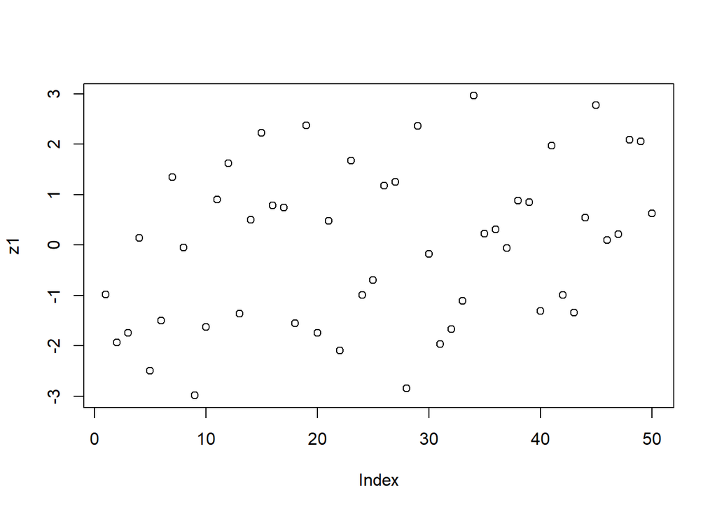

```r
plot(z1)
```

```r
var(z1)
```

```
##          [,1]
## [1,] 2.480242
```

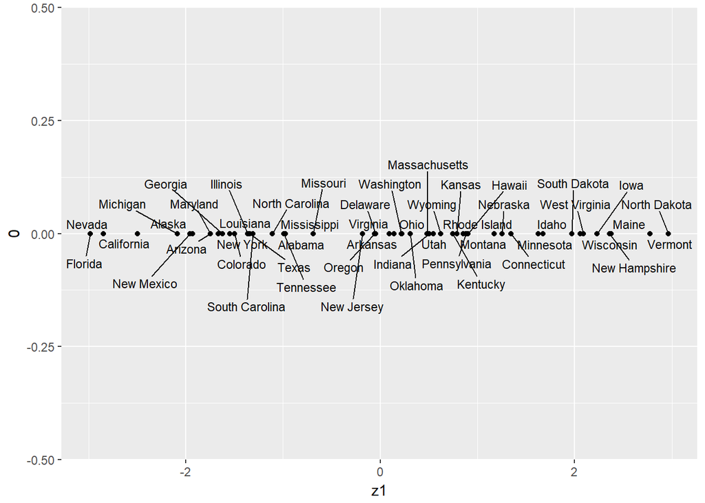

```r
z1df<-data.frame(state<-rownames(z1),z1)
p<- ggplot(z1df, aes(x=z1, y=0))+geom_point() + geom_text_repel(aes(y=0,label=state),size=3)
p
```

## Druga składowa główna:

Kombinacja liniowa:

$z_{2} = \mathbf{\Phi_{2}}\mathbf{x}$

taka, że jest nieskorelowana z $z_{1}$, ma maksymalną wariancję oraz spełnia warunek:

$Cov(z_{2}, z_{1})=0$

co implikuje, że: $\mathbf{\Phi_{2}^{`}}\mathbf{\Phi_{1}}=0$

Wariancja z próby $S_{z_{2}}^2 = \mathbf{\Phi^{`}_{2}}\mathbf{S}\mathbf{\Phi_{2}}$

Poszukujemy wektora maksymalizującego wariancję z próby przy dodatkowych warunkach: $\mathbf{\Phi^{`}_{2}}\mathbf{\Phi_{2}}=1$

oraz

$\mathbf{\Phi^{`}_{2}}\mathbf{\Phi_{1}}=0$

```r
fi2<-as.matrix(fi[,2])

z2<-df.scaled%*%fi2
head(z2)
```

```
##                  [,1]
## Alabama     1.1220012
## Alaska      1.0624269
## Arizona    -0.7384595
## Arkansas    1.1085423
## California -1.5274267
## Colorado   -0.9776297
```

```r
var(z2)
```

```
##           [,1]
## [1,] 0.9897652
```

```r
z12df<-data.frame(z1, z2)
head(z12df)
```

```
##                    z1         z2
## Alabama    -0.9756604  1.1220012
## Alaska     -1.9305379  1.0624269
## Arizona    -1.7454429 -0.7384595
## Arkansas    0.1399989  1.1085423
## California -2.4986128 -1.5274267
## Colorado   -1.4993407 -0.9776297
```

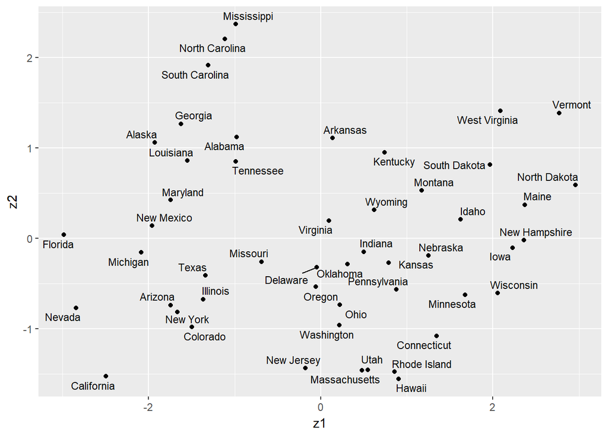

```r
p<- ggplot(z12df, aes(x=z1, y=z2))+geom_point() + geom_text_repel(aes(label=rownames(z12df)),size=3)
p
```

## Kolejne składowe główne , własności

Składowe główne są wzajemnie ortogonalne t.j.

$\mathbf{\Phi^{`}_{j}}\mathbf{\Phi_{k}}=0$ dla wszystkich $j \neq k$

Wariancja z próby każdej składowej głównej jest równa odpowiedniej wartości własnej

Sumwa wariancji z próby składowych głównych jest równa sumie wariancji z próby zmiennych pierwotnych $tr(S)$

## Pomijanie składowych głównych

Składowe nieistotne można pominąć: - procent wariancji () - wykres osypiskowy (piargowy)

```r
sd<-pca[[1]]
var<-sd^2
eigen(S)$values
```

```
## [1] 2.4802416 0.9897652 0.3565632 0.1734301
```

```r
variance.pca<-data.frame("var"=var, "cumvar"=cumsum(var) )
variance.pca$pct_total<-var/sum(var)
variance.pca$cum_pct_total<-variance.pca$cumvar/sum(var)

head(variance.pca)
```

```
##         var   cumvar  pct_total cum_pct_total
## 1 2.4802416 2.480242 0.62006039     0.6200604
## 2 0.9897652 3.470007 0.24744129     0.8675017
## 3 0.3565632 3.826570 0.08914080     0.9566425
## 4 0.1734301 4.000000 0.04335752     1.0000000
```

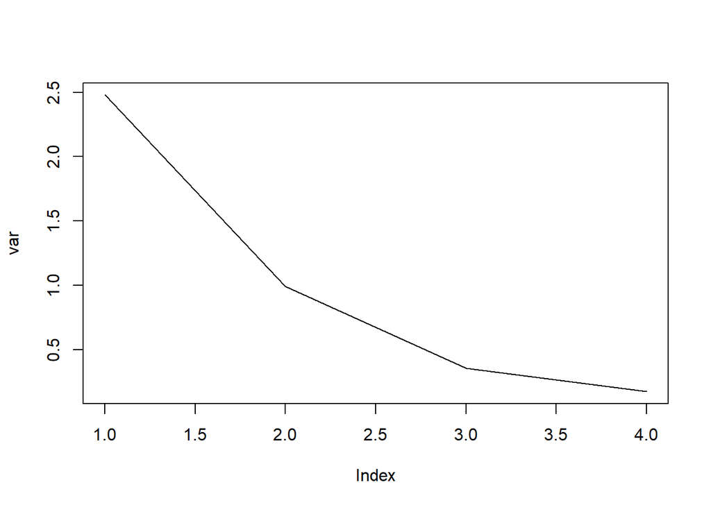

```r
#wykres osypiskowy
plot(var, type="l")
```

```r
library(e1071)
data(iris)
iris
```

[output not shown]

[output cut: 136 more lines]

```r
# model_normal<-glm(NSP1 ~ . -FileName -Date -SegFile -CLASS -NSP -NSP2 -NSP3, data=train, family=binomial)
regr<-naiveBayes( Species~., data=iris, family="binomial")
regr
```

```
##
## Naive Bayes Classifier for Discrete Predictors
##
## Call:
## naiveBayes.default(x = X, y = Y, laplace = laplace, family = "binomial")
##
## A-priori probabilities:
## Y
##     setosa versicolor  virginica
##  0.3333333  0.3333333  0.3333333
##
## Conditional probabilities:
##             Sepal.Length
## Y             [,1]      [,2]
##   setosa     5.006 0.3524897
##   versicolor 5.936 0.5161711
##   virginica  6.588 0.6358796
##
##             Sepal.Width
## Y             [,1]      [,2]
##   setosa     3.428 0.3790644
##   versicolor 2.770 0.3137983
##   virginica  2.974 0.3224966
##
##             Petal.Length
## Y             [,1]      [,2]
##   setosa     1.462 0.1736640
##   versicolor 4.260 0.4699110
##   virginica  5.552 0.5518947
##
##             Petal.Width
## Y             [,1]      [,2]
##   setosa     0.246 0.1053856
##   versicolor 1.326 0.1977527
##   virginica  2.026 0.2746501
```

```r
pSpecies<-predict(regr, iris, type="class")
head(pSpecies)
```

```
## [1] setosa setosa setosa setosa setosa setosa
## Levels: setosa versicolor virginica
```

```r
table(iris$Species,pSpecies)
```

```
##             pSpecies
##              setosa versicolor virginica
##   setosa         50          0         0
##   versicolor      0         47         3
##   virginica       0          3        47
```

```r
## redukujemy

head(iris)
```

```
##   Sepal.Length Sepal.Width Petal.Length Petal.Width Species
## 1          5.1         3.5          1.4         0.2  setosa
## 2          4.9         3.0          1.4         0.2  setosa
## 3          4.7         3.2          1.3         0.2  setosa
## 4          4.6         3.1          1.5         0.2  setosa
## 5          5.0         3.6          1.4         0.2  setosa
## 6          5.4         3.9          1.7         0.4  setosa
```

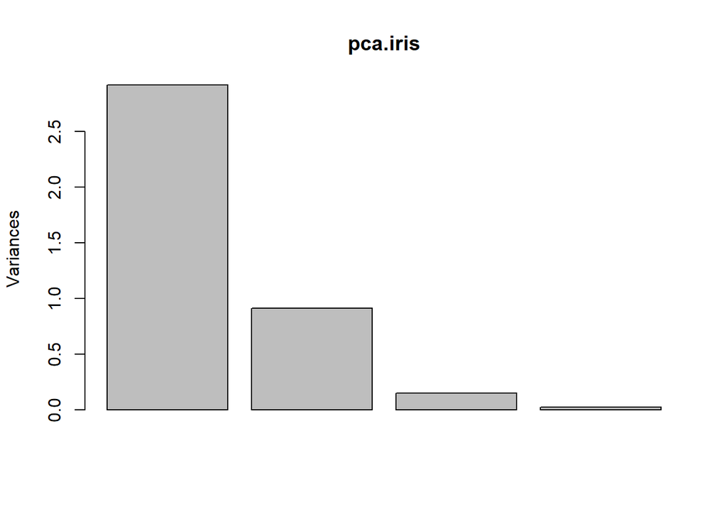

```r
pca.iris<-prcomp(iris[,1:4], scale=TRUE)
plot(pca.iris)
```

```r
#pca.iris$rotation[,1]%*%iris[1,1:4]

head(scale(iris[,1:4]))
```

```
##      Sepal.Length Sepal.Width Petal.Length Petal.Width
## [1,]   -0.8976739  1.01560199    -1.335752   -1.311052
## [2,]   -1.1392005 -0.13153881    -1.335752   -1.311052
## [3,]   -1.3807271  0.32731751    -1.392399   -1.311052
## [4,]   -1.5014904  0.09788935    -1.279104   -1.311052
## [5,]   -1.0184372  1.24503015    -1.335752   -1.311052
## [6,]   -0.5353840  1.93331463    -1.165809   -1.048667
```

```r
#Wektor
head(pca.iris$x)
```

```
##            PC1        PC2         PC3          PC4
## [1,] -2.257141 -0.4784238  0.12727962  0.024087508
## [2,] -2.074013  0.6718827  0.23382552  0.102662845
## [3,] -2.356335  0.3407664 -0.04405390  0.028282305
## [4,] -2.291707  0.5953999 -0.09098530 -0.065735340
## [5,] -2.381863 -0.6446757 -0.01568565 -0.035802870
## [6,] -2.068701 -1.4842053 -0.02687825  0.006586116
```

```r
iris.ds.pca<-data.frame(pca.iris$x)
iris.ds.pca$Species<-iris$Species
head(iris.ds.pca)
```

```
##         PC1        PC2         PC3          PC4 Species
## 1 -2.257141 -0.4784238  0.12727962  0.024087508  setosa
## 2 -2.074013  0.6718827  0.23382552  0.102662845  setosa
## 3 -2.356335  0.3407664 -0.04405390  0.028282305  setosa
## 4 -2.291707  0.5953999 -0.09098530 -0.065735340  setosa
## 5 -2.381863 -0.6446757 -0.01568565 -0.035802870  setosa
## 6 -2.068701 -1.4842053 -0.02687825  0.006586116  setosa
```

```r
nb.pca<-naiveBayes(Species~PC1+PC2+PC3+PC4, data=iris.ds.pca)
pSpecies<-predict(nb.pca, iris.ds.pca, type="class")

table(iris$Species,pSpecies)
```

```
##             pSpecies
##              setosa versicolor virginica
##   setosa         50          0         0
##   versicolor      0         46         4
##   virginica       0          5        45
```